# Traffic Intersection Data

Dan Fanelli

October 19, 2016

Section 5.5 #3 (p222) - Pick a traffic intersection with a traffic light. Collect data on vehicle arrival times and clearing times. Build a Monte Carlo simulation to model traffic flow at this intersection

Note: traffic at the intersection will be analyzed for both the main road (highway, no traffic lights) and the service roada (with traffic lights)

### The Intersection and Traffic Lights (Arial):

(4 Directions: NB-MAIN, SB-MAIN, NB-SER[vice], SB-SER[vice])

[figure not shown]

### The Intersection and Traffic Lights (Map):

[figure not shown]

### ALL data for sample date: (02/05/2013)

|  | ID | Segment_ID | Roadway_Name | xFrom | xTo | Direction | Date | 1 | 2 | 3 | 4 | 5 | 6 | 7 | 8 | 9 | 10 | 11 | 12 | 13 | 14 | 15 | 16 | 17 | 18 | 19 | 20 | 21 | 22 | … |
| --- | --- | --- | --- | --- | --- | --- | --- | --- | --- | --- | --- | --- | --- | --- | --- | --- | --- | --- | --- | --- | --- | --- | --- | --- | --- | --- | --- | --- | --- | --- |
| 5 | 361 | 174566 | HENRY HUDSON PKWY | FAIRFIELD AVE | W 232nd ST | NB-MAIN | 02/05/2013 | 150 | 81 | 51 | 38 | 46 | 71 | 195 | 526 | 1004 | 1035 | 930 | 934 | 960 | 1050 | 1258 | 1802 | 1963 | 2283 | 2354 | 2061 | 1284 | 1173 | … |
| 12 | 361 | 174566 | HENRY HUDSON PKWY | FAIRFIELD AVE | W 232nd ST | NB-SER | 02/05/2013 | 5 | 8 | 4 | 11 | 5 | 17 | 35 | 87 | 104 | 90 | 62 | 69 | 71 | 99 | 97 | 92 | 98 | 86 | 65 | 42 | 53 | 40 | … |
| 19 | 361 | 174566 | HENRY HUDSON PKWY | FAIRFIELD AVE | W 232nd ST | SB-MAIN | 02/05/2013 | 114 | 29 | 39 | 44 | 68 | 283 | 1317 | 2865 | 3067 | 2468 | 1896 | 1401 | 1357 | 1207 | 1259 | 1727 | 2108 | 2358 | 2183 | 1367 | 858 | 816 | … |
| 26 | 361 | 174566 | HENRY HUDSON PKWY | FAIRFIELD AVE | W 232nd ST | SB-SER | 02/05/2013 | 20 | 9 | 4 | 4 | 9 | 15 | 87 | 226 | 286 | 210 | 157 | 116 | 135 | 136 | 143 | 190 | 174 | 167 | 158 | 125 | 93 | 83 | … |
| 33 | 251 | 73220 | HENRY HUDSON PKWY | INDEPENDENCE AVE | W 232nd ST | NB-MAIN | 02/05/2013 | 254 | 108 | 64 | 34 | 31 | 78 | 300 | 908 | 1656 | 1091 | 837 | 898 | 898 | 995 | 1217 | 1718 | 1990 | 2347 | 2418 | 2155 | 1312 | 1269 | … |
| 40 | 251 | 73220 | HENRY HUDSON PKWY | INDEPENDENCE AVE | W 232nd ST | NB-SER | 02/05/2013 | 13 | 15 | 4 | 7 | 10 | 16 | 37 | 130 | 186 | 109 | 127 | 98 | 118 | 96 | 121 | 148 | 142 | 133 | 143 | 132 | 79 | 65 | … |
| 47 | 251 | 73220 | HENRY HUDSON PKWY | INDEPENDENCE AVE | W 232nd ST | SB-MAIN | 02/05/2013 | 126 | 33 | 42 | 46 | 73 | 297 | 1371 | 3137 | 3418 | 2723 | 2043 | 1494 | 1461 | 1306 | 1354 | 1848 | 2225 | 2478 | 2286 | 1458 | 931 | 881 | … |
| 54 | 251 | 73220 | HENRY HUDSON PKWY | INDEPENDENCE AVE | W 232nd ST | SB-SER | 02/05/2013 | 7 | 11 | 4 | 3 | 5 | 7 | 20 | 69 | 99 | 79 | 58 | 48 | 70 | 83 | 82 | 96 | 90 | 63 | 73 | 55 | 41 | 30 | … |

### Transform (Reshape) to Long Format:

(with DATE and HOUR fields.)

|  | ID | Segment_ID | Roadway_Name | xFrom | xTo | Direction | Date | HOUR | value |
| --- | --- | --- | --- | --- | --- | --- | --- | --- | --- |
| 5 | 361 | 174566 | HENRY HUDSON PKWY | FAIRFIELD AVE | W 232nd ST | NB-MAIN | 02/05/2013 | 1 | 150 |
| 12 | 361 | 174566 | HENRY HUDSON PKWY | FAIRFIELD AVE | W 232nd ST | NB-SER | 02/05/2013 | 1 | 5 |
| 19 | 361 | 174566 | HENRY HUDSON PKWY | FAIRFIELD AVE | W 232nd ST | SB-MAIN | 02/05/2013 | 1 | 114 |
| 26 | 361 | 174566 | HENRY HUDSON PKWY | FAIRFIELD AVE | W 232nd ST | SB-SER | 02/05/2013 | 1 | 20 |
| 33 | 251 | 73220 | HENRY HUDSON PKWY | INDEPENDENCE AVE | W 232nd ST | NB-MAIN | 02/05/2013 | 1 | 254 |
| 40 | 251 | 73220 | HENRY HUDSON PKWY | INDEPENDENCE AVE | W 232nd ST | NB-SER | 02/05/2013 | 1 | 13 |
| 47 | 251 | 73220 | HENRY HUDSON PKWY | INDEPENDENCE AVE | W 232nd ST | SB-MAIN | 02/05/2013 | 1 | 126 |
| 54 | 251 | 73220 | HENRY HUDSON PKWY | INDEPENDENCE AVE | W 232nd ST | SB-SER | 02/05/2013 | 1 | 7 |
| 61 | 361 | 174566 | HENRY HUDSON PKWY | FAIRFIELD AVE | W 232nd ST | NB-MAIN | 02/05/2013 | 2 | 81 |
| 68 | 361 | 174566 | HENRY HUDSON PKWY | FAIRFIELD AVE | W 232nd ST | NB-SER | 02/05/2013 | 2 | 8 |

### HOURLY data for sample date: (02/05/2013)

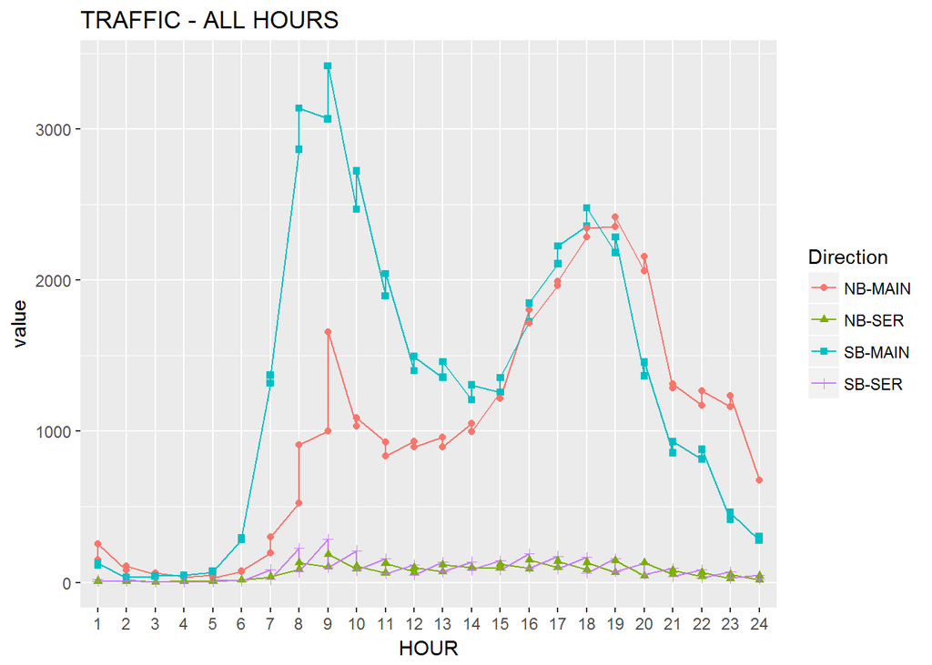

Hourly data is NOT RANDOM, so Monte Carlo simulation not applicable. Let’s Analze traffic ONLY in *4th* HOUR OF THE DAY across multiple days, since perhaps the daily traffic levels will be RANDOM AT THAT TIME and Monte Carlo simulation will then be applicable:

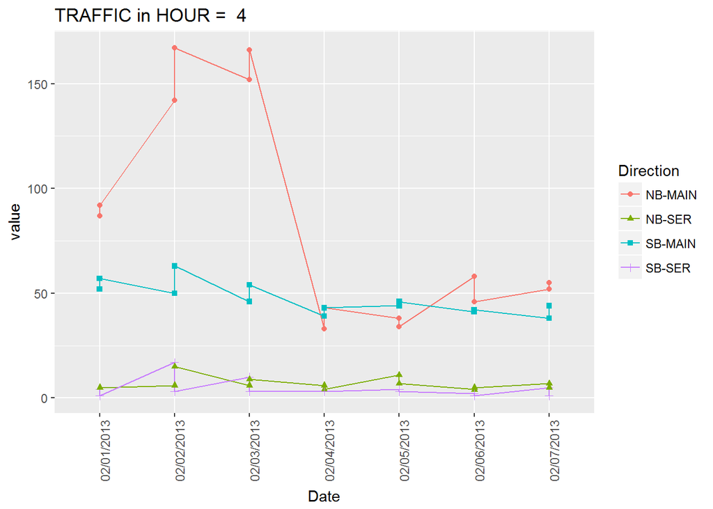

Seems to have some days that are not random, why?

[figure not shown]

- Feb 2 and 3 in were Saturday and Sunday
- This explains the extra valume
- So let’s only look at the last 4 for rush hour analysis.

### North/South TRAFFIC DATA at HOUR #4:

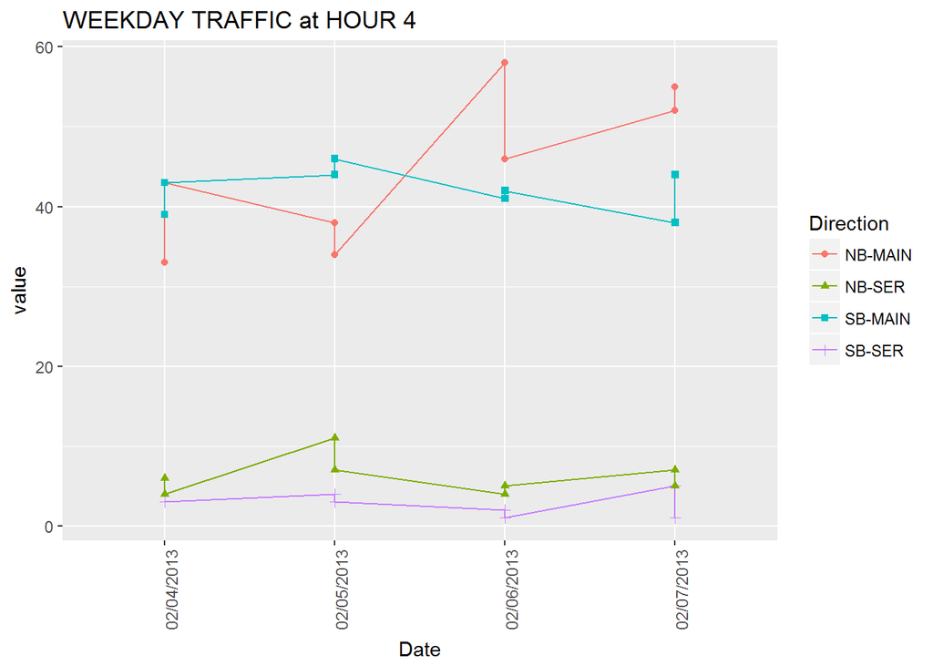

It seems more possible that these values are random, so let’s inspect the data for a single day:

| ID | Segment_ID | Roadway_Name | xFrom | xTo | Direction | Date | HOUR | value |
| --- | --- | --- | --- | --- | --- | --- | --- | --- |
| 361 | 174566 | HENRY HUDSON PKWY | FAIRFIELD AVE | W 232nd ST | NB-MAIN | 02/05/2013 | 4 | 38 |
| 251 | 73220 | HENRY HUDSON PKWY | INDEPENDENCE AVE | W 232nd ST | NB-MAIN | 02/05/2013 | 4 | 34 |
| 361 | 174566 | HENRY HUDSON PKWY | FAIRFIELD AVE | W 232nd ST | NB-SER | 02/05/2013 | 4 | 11 |
| 251 | 73220 | HENRY HUDSON PKWY | INDEPENDENCE AVE | W 232nd ST | NB-SER | 02/05/2013 | 4 | 7 |
| 361 | 174566 | HENRY HUDSON PKWY | FAIRFIELD AVE | W 232nd ST | SB-MAIN | 02/05/2013 | 4 | 44 |
| 251 | 73220 | HENRY HUDSON PKWY | INDEPENDENCE AVE | W 232nd ST | SB-MAIN | 02/05/2013 | 4 | 46 |
| 361 | 174566 | HENRY HUDSON PKWY | FAIRFIELD AVE | W 232nd ST | SB-SER | 02/05/2013 | 4 | 4 |
| 251 | 73220 | HENRY HUDSON PKWY | INDEPENDENCE AVE | W 232nd ST | SB-SER | 02/05/2013 | 4 | 3 |

## Monte Carlo Simulation:

Find p-value for *null hypothesis*: “In hour *4* on a weekday, the northbound and southbound traffic are equal.”

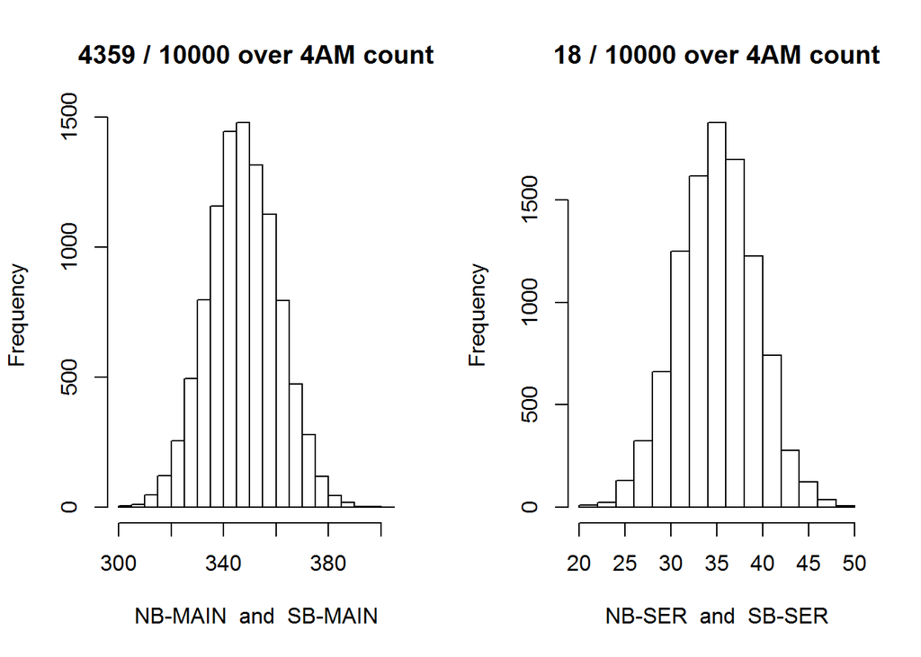

### Therefore:

The probability that *MAIN* road fits null hypothesis (no direction bias) at hour *4* is: *0.4359*

The probability that *SERVICE* road fits null hypothes (no direction bias) at hour *4* is: *0.0018*

## All Code:

```r
HOUR_OF_DAY_TO_USE <- 4
SAMPLE_DATE <- '02/05/2013'
NUM_RUNS_TO_PERFORM <- 10000#0
library(ggplot2)
library(knitr)
library(sqldf)

traffic <- read.csv(file="Traffic_Volume_Counts__2012-2013_.csv",header=TRUE,sep=",");

names(traffic) <- gsub(".", "_", names(traffic), fixed = TRUE)

colnames(traffic)[which(names(traffic) == "From")] <- "xFrom"
colnames(traffic)[which(names(traffic) == "To")] <- "xTo"
colnames(traffic)[which(names(traffic) == "Roadway Name")] <- "Roadway_Name"

all_data <- sqldf("select * from traffic where Roadway_Name = 'HENRY HUDSON PKWY' and direction in ('NB-MAIN','SB-MAIN','NB-SER','SB-SER') and xTo = 'W 232nd ST' and Date like '%2013' order by trim(xFrom)")

for(new_col_name in c(8:31)){
  colnames(all_data)[new_col_name] <- (new_col_name-7)
}

kable(all_data[all_data$Date == SAMPLE_DATE,])

library(reshape2)
all_data <- melt(all_data, id.vars = c("ID", "Segment_ID", "Roadway_Name", "xFrom", "xTo", "Direction", "Date"))

colnames(all_data)[8] <- "HOUR"

all_data <- all_data[order(all_data$Date, all_data$HOUR, all_data$Roadway_Name, all_data$xFrom, all_data$xTo),]

# SHOW THAT THE RESHAPE WORKED AS PLANNED
kable(head(all_data[all_data$Date == SAMPLE_DATE,], n=10))

ggplot(data=all_data[all_data$Date == SAMPLE_DATE,], aes(x=HOUR, y=value, group=Direction, shape=Direction, color=Direction)) + ggtitle("TRAFFIC - ALL HOURS") + geom_line() + geom_point()

ggplot(data=all_data[all_data$HOUR == HOUR_OF_DAY_TO_USE,], aes(x=Date, y=value, group=Direction, shape=Direction, color=Direction)) + ggtitle(paste("TRAFFIC in HOUR = ",HOUR_OF_DAY_TO_USE)) + geom_line() + geom_point() + theme(axis.text.x = element_text(angle = 90, hjust = 1))

weekdays_data <- all_data[all_data$HOUR == HOUR_OF_DAY_TO_USE,]
#DATES_TO_USE <- c('02/01/2013','02/04/2013','02/05/2013','02/06/2013','02/07/2013')
DATES_TO_USE <- c('02/04/2013','02/05/2013','02/06/2013','02/07/2013')
weekdays_data <- weekdays_data[weekdays_data$Date %in% DATES_TO_USE,]

ggplot(data=weekdays_data, aes(x=Date, y=value, group=Direction, shape=Direction, color=Direction)) + ggtitle(paste("WEEKDAY TRAFFIC at HOUR",HOUR_OF_DAY_TO_USE)) + geom_line() + geom_point() + theme(axis.text.x = element_text(angle = 90, hjust = 1))

single_weekday_data <- weekdays_data[weekdays_data$Date == SAMPLE_DATE,]

kable(sqldf("select *  from single_weekday_data order by Direction, xFrom, xTo"))
nb_sb_for <- function(NB_TEXT_VAL, SB_TEXT_VAL){
  nb_sum <- sum(weekdays_data[weekdays_data$Direction == NB_TEXT_VAL, ]$value)
  nb_sum
  sb_sum <- sum(weekdays_data[weekdays_data$Direction == SB_TEXT_VAL, ]$value)
  sb_sum

  total_traffic_count_main <- nb_sum + sb_sum
  nb_sum_samples <- c()
  count_over_threshold <- 0
  for(run_num in 1:NUM_RUNS_TO_PERFORM){
    total_1s <- sum(sample(c(0,1),total_traffic_count_main,replace = TRUE))
    nb_sum_samples <- c(nb_sum_samples,total_1s)
    # 2-sided p-test
    if(total_1s >= nb_sum || total_1s <= sb_sum){
      count_over_threshold <- count_over_threshold + 1
    }
  }

  hist(nb_sum_samples, xlab = paste(NB_TEXT_VAL," and ", SB_TEXT_VAL), main = paste(count_over_threshold,"/",NUM_RUNS_TO_PERFORM,"over 4AM count"))
  return (count_over_threshold/NUM_RUNS_TO_PERFORM)
}

par(mfrow=c(1,2))
main_probs <- nb_sb_for('NB-MAIN','SB-MAIN')
service_probs <- nb_sb_for('NB-SER','SB-SER')
```